# Análisis del ruido en Madrid

Este notebook presenta un análisis del índice de ruido $LA_{eq}^{(i)}$ en la ciudad de Madrid para los años 2015-2019, ambos incluidos, y el año 2020 hasta el mes de mayo.

i El índice de ruido $LA_{eq}$ es el parámetro acústico aceptado internacionalmente como medida del nivel sonoro continuo equivalente. Este índice representa la contaminación acústica acumulada a lo largo de un periodo de tiempo en el lugar de medición. Puesto que el oído humano es más sensible a las medias frecuencias, se realiza una ponderación de frecuencias, dando menos importancia a las bajas y altas frecuencias frente a las medias, con el fin de establecer una medida del nivel de ruido que soporta el ser humano cercano a la estación de medición.

Análisis realizado por ClaudiaGEscribano y ddzumajo

Los datos han sido obtenido del [Portal de datos abiertos del Ayuntamiento de Madrid](https://datos.madrid.es/portal/site/egob/menuitem.c05c1f754a33a9fbe4b2e4b284f1a5a0/?vgnextoid=2ec892874870b410VgnVCM1000000b205a0aRCRD&vgnextchannel=374512b9ace9f310VgnVCM100000171f5a0aRCRD&vgnextfmt=default).

```r
library("dplyr")
library("ggplot2")
library("gridExtra")
library("reshape2")
library("magrittr")
library("lattice")
library("latticeExtra")
library("zoo")
library("viridis")
```

```r
Sys.setlocale("LC_TIME", "en_US.UTF-8")
```

```
[1] "en_US.UTF-8"
```

```r
# Set the minimal set for the graphs
theme_set(theme_minimal() + theme(legend.position = "top"))
```

```r
# Load data
df <- read.csv(file = './data/datos_ruido_madrid.csv', header = FALSE, sep = ';', strip.white = TRUE)
# Rename columns
colnames(df) <- c("Station","Year","Month","Day","Period","LAeq","LAS01","LAS10","LAS50","LAS90","LAS99")
# Create column date
df$Date <- as.Date(with(df, paste(Year, Month, Day,sep="-")), "%Y-%m-%d")
# Create column with the name of the months
df$MonthName <- months(df$Date)
# Create column with day of week and month.
df$DayMonthName <- with(df, paste(weekdays(df$Date), MonthName,sep="-"))
# Delete useless columns
df$LAS01 <- NULL
df$LAS10 <- NULL
df$LAS50 <- NULL
df$LAS90 <- NULL
df$LAS99 <- NULL
head(df)
```

|  | Station | Year | Month | Day | Period | LAeq | Date | MonthName | DayMonthName |
| --- | --- | --- | --- | --- | --- | --- | --- | --- | --- |
| 1 | 1 | 2015 | 12 | 31 | D | 69.1 | 2015-12-31 | December | Thursday-December |
| 2 | 1 | 2015 | 12 | 31 | E | 70.7 | 2015-12-31 | December | Thursday-December |
| 3 | 1 | 2015 | 12 | 31 | N | 66.7 | 2015-12-31 | December | Thursday-December |
| 4 | 1 | 2015 | 12 | 31 | T | 68.9 | 2015-12-31 | December | Thursday-December |
| 5 | 2 | 2015 | 12 | 31 | D | 74.1 | 2015-12-31 | December | Thursday-December |
| 6 | 2 | 2015 | 12 | 31 | E | 74.0 | 2015-12-31 | December | Thursday-December |

```r
# Load stations file
dfs <- read.csv(file = './data/EstacionesMedidaControlAcustico.csv', header = TRUE, sep = ',', strip.white = TRUE, fileEncoding = "ISO-8859-1")
# Delete useless columns
dfs[ ,c('COD_VIA', 'VIA_CLASE','VIA_PAR','VIA_NOMBRE','Dirección','Longitud_gms','Latitud_gms','LATITUD_ED50','LONGITUD_ED50','Alt..m.','Fecha.alta','Coordenada_X_ETRS89','Coordenada_Y_ETRS89','LONGITUD_WGS84','LATITUD_WGS84','X.2','X.3')] <- list(NULL)
# Rename some columns
dfs <- dfs %>%
  rename(
    Station=Nº,
    StationName = Nombre,
    Long = X,
    Lat = X.1
    )
head(dfs)
```

|  | Station | StationName | Long | Lat |
| --- | --- | --- | --- | --- |
| 1 | 1 | Pº Recoletos | -3.691926 | 40.42262 |
| 2 | 2 | Carlos V | -3.691490 | 40.40911 |
| 3 | 3 | Plaza del Carmen | -3.703166 | 40.41921 |
| 4 | 4 | Plaza de España | -3.712257 | 40.42388 |
| 5 | 5 | Bº del Pilar | -3.711536 | 40.47823 |
| 6 | 6 | Gregorio Marañón | -3.690785 | 40.43757 |

```r
# Merge dataframes
df <- merge(df, dfs, by = "Station", all.x = TRUE)
# Sort output dataframe
df <- df[order(df$Date),]
head(df)
```

|  | Station | Year | Month | Day | Period | LAeq | Date | MonthName | DayMonthName | StationName | Long | Lat |
| --- | --- | --- | --- | --- | --- | --- | --- | --- | --- | --- | --- | --- |
| 3151 | 1 | 2015 | 1 | 1 | D | 66.8 | 2015-01-01 | January | Thursday-January | Pº Recoletos | -3.691926 | 40.42262 |
| 5751 | 1 | 2015 | 1 | 1 | T | 67.9 | 2015-01-01 | January | Thursday-January | Pº Recoletos | -3.691926 | 40.42262 |
| 6481 | 1 | 2015 | 1 | 1 | E | 67.9 | 2015-01-01 | January | Thursday-January | Pº Recoletos | -3.691926 | 40.42262 |
| 19813 | 3 | 2015 | 1 | 1 | D | 60.1 | 2015-01-01 | January | Thursday-January | Plaza del Carmen | -3.703166 | 40.41921 |
| 20348 | 3 | 2015 | 1 | 1 | T | 68.6 | 2015-01-01 | January | Thursday-January | Plaza del Carmen | -3.703166 | 40.41921 |
| 21161 | 3 | 2015 | 1 | 1 | N | 72.9 | 2015-01-01 | January | Thursday-January | Plaza del Carmen | -3.703166 | 40.41921 |

A continuación se muestran los registros del índice $LA_{eq}$ medidos por todas las estaciones a lo largo de los años para los distintos periodos. Se observa que durante las noches (N) el índice es inferior en todas la estaciones. Por otro lado, en algunas estaciones apenas hay distinción en el índice de ruido medido en los periodos D y E (mañana y tarde, respectivamente).

Además, se aprecia con claridad cómo el índice de ruido es estacional (se repite el mismo patrón de año en año), si bien se observan diferencias para el año 2020 debido a las medidas de confinamiento para paliar el efecto de la pandemia COVID-19.

Los picos observados seguramente sean debidos a errores en la medición del ruido.

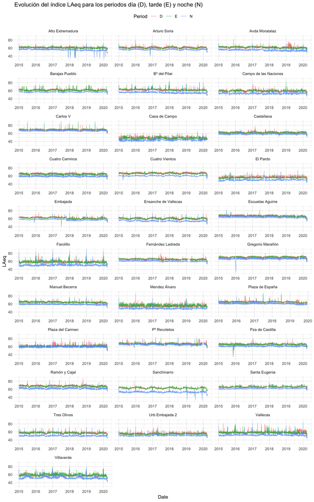

```r
ggplot(df[df$Period != "T", ], aes(x = Date, y = LAeq, group=Period)) +
  geom_line(aes(color=Period), alpha=0.8, lwd = 0.3)  +
  facet_wrap(~ StationName, ncol = 3, scales="free_x") +
  ylim(30,90) +
  labs(title = "Evolución del índice LAeq para los periodos día (D), tarde (E) y noche (N)", y = "LAeq") +
  scale_x_date(date_breaks = "years", date_labels = "%Y")
```

Realizamos la media del índice $LA_{eq}$ en el periodo T a lo largo de los años 2015-2019 (ambos incluidos) para cada una de las estaciones. De esta manera podemos ver cuáles son las estaciones que generalmente son más ruidosas.

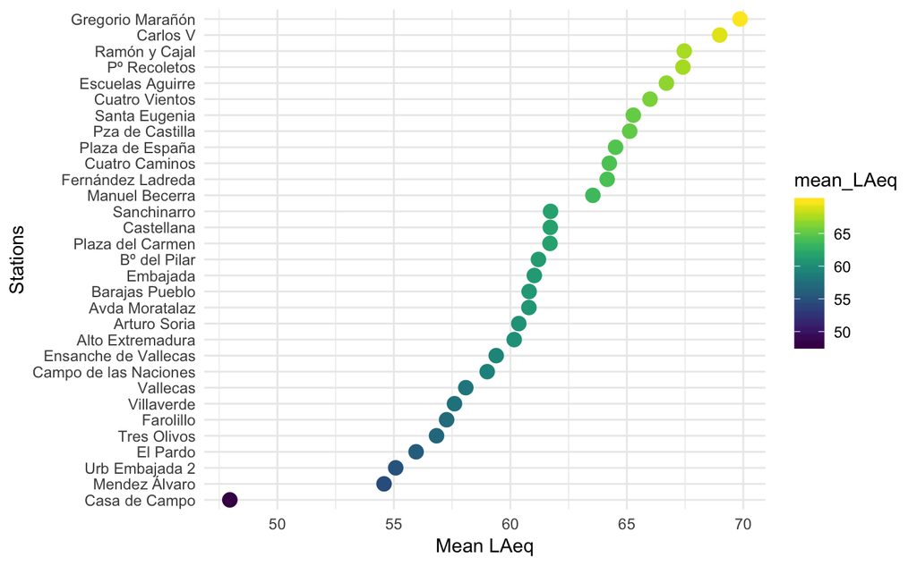

```r
dfToPlot <-df %>%
  filter(Year != 2020) %>%
  filter(Period == "T") %>%
  group_by(StationName) %>%
  summarise(mean_LAeq = mean(LAeq))
ggplot(dfToPlot,aes(y=reorder(StationName, mean_LAeq, mean),x=mean_LAeq, color=mean_LAeq)) +
  geom_point(cex=3.5) +
  scale_color_viridis(option = "D") +
  labs(y="Stations", x = "Mean LAeq") +
  theme(legend.position = "right")
```